# Lab 4. Area Data Modeling

Spatial Big Data Analysis with GIS (jaehongjeong@hanyang.ac.kr)

Korean Statistical Society, Winter School, February 24, 2023

This document is based on “Hierarchical Modeling and Analysis for Spatial Data” by Banerjee, Carlin, and Gelfand (https://conservancy.umn.edu/handle/11299/200500).

```r
# Required packages
library(spdep)
library(maps)
library(maptools)
library(classInt)
library(RColorBrewer)
library(spData)
library(spatialreg)
```

# 1 Area Data Modeling

We outline the use of some GIS functions in ${\tt R}$ for obtaining neighborhood (adjacency) matrices, computing Moran’s and Geary’s statistic and fitting CAR and SAR models using traditional maximum likelihood techniques, and mapping the results for certain classes of problems.

## 1.1 Computing Moran’s I and Geary’s C

We can invoke the ${\tt moran.test}$ (or ${\tt moran.mc}$) and ${\tt geary.test}$ functions in the ${\tt spdep}$ package to obtain Moran’s $I$ and Geary’s $C$ statistics.

```r
#library(spdep)
#library(maps)
#library(maptools)
#library(classInt)
#library(RColorBrewer)
#library(spData)
#library(spatialreg)

usa.state <- map(database="state",fill=TRUE,plot=FALSE)
state.ID <- sapply(strsplit(usa.state$names,":"),function(x) x[1])
usa.poly <- map2SpatialPolygons(usa.state,IDs=state.ID)
usa.nb <- poly2nb(usa.poly)

usa.adj.mat <- nb2mat(usa.nb,style="B")

usa.listw <- nb2listw(usa.nb,style="W")

state.sat.scores <- read.table("../Dataset/state-sat.dat",header=FALSE)

verbal <- c(state.sat.scores$V2[1],state.sat.scores$V2[3:11],state.sat.scores$V2[13:51])

moran.test(verbal,listw=usa.listw)
```

```
##
##  Moran I test under randomisation
##
## data:  verbal
## weights: usa.listw
##
## Moran I statistic standard deviate = 6.4706, p-value = 4.88e-11
## alternative hypothesis: greater
## sample estimates:
## Moran I statistic       Expectation          Variance
##       0.612539264      -0.020833333       0.009581325
```

```r
geary.test(verbal,listw=usa.listw)
```

```
##
##  Geary C test under randomisation
##
## data:  verbal
## weights: usa.listw
##
## Geary C statistic standard deviate = 6.5288, p-value = 3.315e-11
## alternative hypothesis: Expectation greater than statistic
## sample estimates:
## Geary C statistic       Expectation          Variance
##       0.357738128       1.000000000       0.009677403
```

Using the 1999 average verbal SAT scores, lower 48 U.S. states and the district of Columbia, the sample estimate of Moran’s I and standard error are 0.6125 and 0.0979, respectively. Greary’s C yields the sample estimate and standard error of 0.3577 and 0.0984.

## 1.2 SAR and CAR modeling

### 1.2.1 Sudden Infant Death Syndrome (SIDS)

We turn to fitting spatial autoregression models using available functions in the ${\tt spdep}$ package. The dataset can be read from a shapefile ${\tt sids.shp}$ and an ${\tt nb}$ object. The data relates to counts aggregated from 1979 to 1983. This dataset contains counts of SIDS deaths from 1974 to 1978 and counts from 1979 to 1983 along with related covariate information for the 100 counties in the U.S. State of North Carolina (https://geodacenter.github.io/data-and-lab/sids/).

```r
nc.sids <- st_read(system.file("shapes/sids.shp", package="spData")[1], quiet=TRUE)
rn <- as.character(nc.sids$FIPS)
ncCC89_nb <- read.gal(system.file("weights/ncCC89.gal", package="spData")[1],
region.id=rn)


##Create a map of raw SIDS rates
##First create a vector of rates from counts
nc.sids.rates.raw <- probmap(nc.sids$SID79, nc.sids$BIR79)$raw
##Alternatvely, one may want to use Freeman-Tukey transformations
nc.sids.rates.FT <- sqrt(1000) * (sqrt(nc.sids$SID79/nc.sids$BIR79) + sqrt((nc.sids$SID79 + 1)/nc.sids$BIR79))

##Append the rates we want to plot to the nc.sids data frame
nc.sids$rates.FT <- nc.sids.rates.FT

brks <- c(0, 2.0, 3.0, 3.5, 6.0)
#spplot(nc.sids, "rates.FT", at = brks, col.regions = rev(brewer.pal(4,"RdBu")))

#turn neighborhoods into list info
ncCC89.listw <- nb2listw(ncCC89.nb,style="B", zero.policy = TRUE)

##Compute Moran's I and Geary's C
##ncCR85.listw = nb2listw(ncCR85.nb, style="W", zero.policy=TRUE)
nc.sids.moran.out <- moran.test(nc.sids.rates.FT, listw=ncCC89.listw, zero.policy=TRUE)
nc.sids.moran.out
```

```
##
##  Moran I test under randomisation
##
## data:  nc.sids.rates.FT
## weights: ncCC89.listw  n reduced by no-neighbour observations
##
##
## Moran I statistic standard deviate = 1.5029, p-value = 0.06643
## alternative hypothesis: greater
## sample estimates:
## Moran I statistic       Expectation          Variance
##       0.093469598      -0.010309278       0.004768116
```

```r
nc.sids.geary.out <- geary.test(nc.sids.rates.FT, listw=ncCC89.listw, zero.policy=TRUE)
nc.sids.geary.out
```

```
##
##  Geary C test under randomisation
##
## data:  nc.sids.rates.FT
## weights: ncCC89.listw
##
## Geary C statistic standard deviate = 1.2798, p-value = 0.1003
## alternative hypothesis: Expectation greater than statistic
## sample estimates:
## Geary C statistic       Expectation          Variance
##       0.882964158       1.000000000       0.008362327
```

```r
##find islands
nc.county.id <- attr(ncCC89.nb,"region.id")
nc.no.neighbors <- card(ncCC89.nb)
nc.islands <- as.character(nc.sids[card(ncCC89.nb)==0,]$NAME)
nc.islands # Two counties, Dare and Hyde, have zero neighbors.
```

```
## [1] "Dare" "Hyde"
```

```r
#Feedman-Tukey transformation (to get Gaussian) on SIDS rates
nc.sides.rates.FT <- sqrt(1000)*(sqrt(nc.sids$SID79/nc.sids$BIR79)
                                + sqrt((nc.sids$SID79+1)/nc.sids$BIR79))
nc.sids$rates.FT <- nc.sides.rates.FT

#Feedman-Tukey transformation (to get Gaussian) on SIDS rates for non-white births
nc.sid.nwbir.FT <- sqrt(1000)*(sqrt(nc.sids$NWBIR79/nc.sids$BIR79)
                              + sqrt((nc.sids$NWBIR79+1)/nc.sids$BIR79))
nc.sids$nwbir.FT <- nc.sid.nwbir.FT


#Fit a SAR model (replace family = "SAR" with family = "CARfixedBreaks, to fit a CAR model)
nc.sids.sar.out <- spautolm(rates.FT~nwbir.FT, data=nc.sids,family="SAR",
listw <- ncCC89.listw,zero.policy = TRUE)

summary(nc.sids.sar.out)
```

```
##
## Call:
## spautolm(formula = rates.FT ~ nwbir.FT, data = nc.sids, listw = listw <- ncCC89.listw,
##     family = "SAR", zero.policy = TRUE)
##
## Residuals:
##       Min        1Q    Median        3Q       Max
## -2.266049 -0.428139  0.004331  0.497818  2.516498
##
## Regions with no neighbours included:
##  2000 2099
##
## Coefficients:
##              Estimate Std. Error z value Pr(>|z|)
## (Intercept) 2.5216462  0.2570334  9.8106  < 2e-16
## nwbir.FT    0.0124001  0.0071867  1.7254  0.08445
##
## Lambda: 0.05206 LR test value: 2.218 p-value: 0.13641
## Numerical Hessian standard error of lambda: 0.033696
##
## Log likelihood: -123.6898
## ML residual variance (sigma squared): 0.68697, (sigma: 0.82883)
## Number of observations: 100
## Number of parameters estimated: 4
## AIC: 255.38
```

```r
##CAR model regressing rates.FT on NWBIR79.FT
nc.sids.car.out <- spautolm(rates.FT~ nwbir.FT, data=nc.sids, family="CAR", listw=ncCC89.listw, zero.policy=TRUE)
nc.sids.car.fitted <- fitted(nc.sids.car.out)
nc.sids$fitted.car <- nc.sids.car.fitted

summary(nc.sids.car.out)
```

```
##
## Call:
## spautolm(formula = rates.FT ~ nwbir.FT, data = nc.sids, listw = ncCC89.listw,
##     family = "CAR", zero.policy = TRUE)
##
## Residuals:
##       Min        1Q    Median        3Q       Max
## -2.202149 -0.408797  0.022183  0.459177  2.590967
##
## Regions with no neighbours included:
##  2000 2099
##
## Coefficients:
##              Estimate Std. Error z value Pr(>|z|)
## (Intercept) 2.5148477  0.2584345  9.7311  < 2e-16
## nwbir.FT    0.0126925  0.0072129  1.7597  0.07846
##
## Lambda: 0.094278 LR test value: 2.1267 p-value: 0.14475
## Numerical Hessian standard error of lambda: 0.057078
##
## Log likelihood: -123.7354
## ML residual variance (sigma squared): 0.68151, (sigma: 0.82554)
## Number of observations: 100
## Number of parameters estimated: 4
## AIC: 255.47
```

```r
#plot rates.FT
brks <- c(0,2.0,3.0,3.5,6.0)
color.pallete <- rev(brewer.pal(4,"RdBu"))
class.fitted <- classIntervals(var=nc.sids$rates.FT,n=4,style="fixed",
fixedBreaks=brks,dataPrecision=4)
class.fitted
```

```
## style: fixed
##   one of 156,849 possible partitions of this variable into 4 classes
##   [0,2)   [2,3) [3,3.5) [3.5,6]
##      12      41      28      19
```

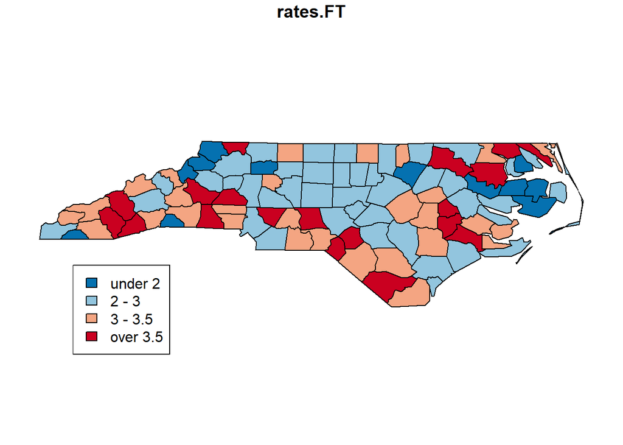

```r
color.code.fitted <- findColours(class.fitted, color.pallete)
brks <- c(-Inf,2,3,3.5,Inf)
plot(nc.sids[,24],col=color.code.fitted)
legend("bottomleft", fill=color.pallete, legend=leglabs(brks))
```

(Figure above) Raw Freeman-Tukey transformed SIDS rates (Note: FTT seeks to adjust data to make the distribution more similar to a Normal distribution.)

```r
#plot SAR predictions
nc.sids$fitted.sar <- fitted(nc.sids.sar.out)
brks <- c(0,2.0,3.0,3.5,6.0)
color.pallete <- rev(brewer.pal(4,"RdBu"))
class.fitted <- classIntervals(var=nc.sids$fitted.sar,n=4,style="fixed",
fixedBreaks=brks,dataPrecision=4)
class.fitted
```

```
## style: fixed
##   one of 156,849 possible partitions of this variable into 4 classes
##   [0,2)   [2,3) [3,3.5) [3.5,6]
##       0      69      31       0
```

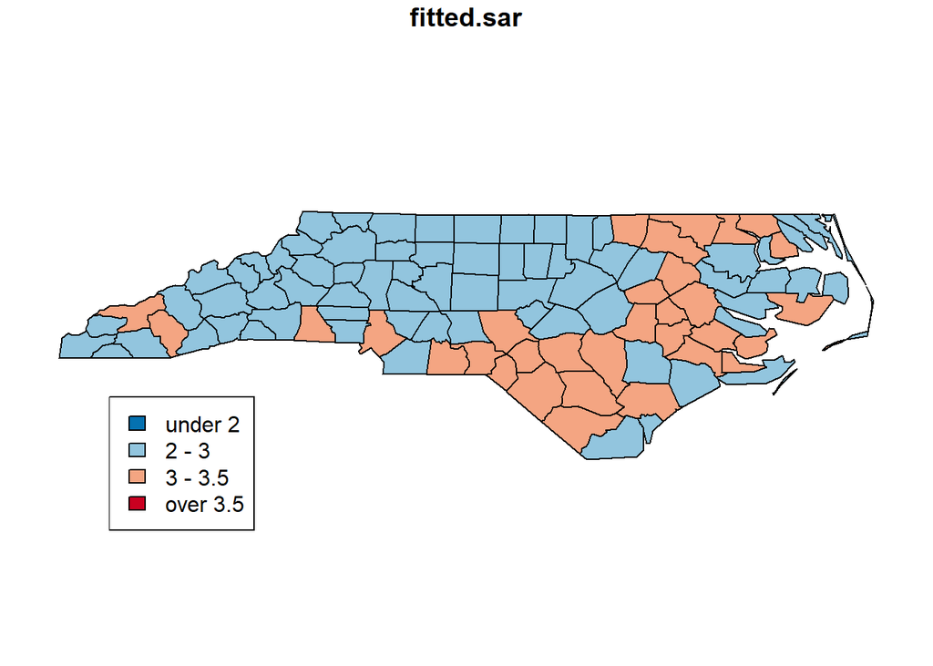

```r
color.code.fitted <- findColours(class.fitted, color.pallete)
brks <- c(-Inf,2,3,3.5,Inf)
plot(nc.sids[,27],col = color.code.fitted)
legend("bottomleft", fill=color.pallete, legend=leglabs(brks))
```

(Figure above) Fitted SIDS rates from SAR model

```r
#plot CAR predictions
nc.sids$fitted.car <- fitted(nc.sids.car.out)
brks <- c(0,2.0,3.0,3.5,6.0)
color.pallete <- rev(brewer.pal(4,"RdBu"))
class.fitted <- classIntervals(var=nc.sids$fitted.car,n=4,style="fixed",
fixedBreaks=brks,dataPrecision=4)
class.fitted
```

```
## style: fixed
##   one of 156,849 possible partitions of this variable into 4 classes
##   [0,2)   [2,3) [3,3.5) [3.5,6]
##       0      70      29       1
```

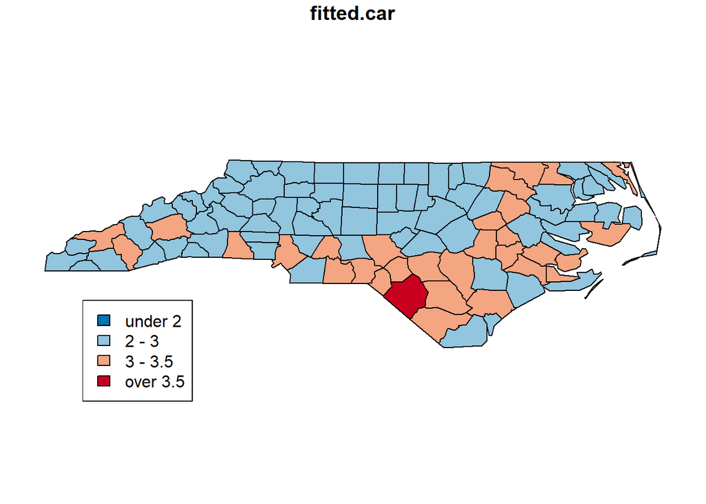

```r
color.code.fitted <- findColours(class.fitted, color.pallete)
brks <- c(-Inf,2,3,3.5,Inf)
plot(nc.sids[,26],col = color.code.fitted)
legend("bottomleft", fill=color.pallete, legend=leglabs(brks))
```

(Figure above) Fitted SIDS rates from CAR model

### 1.2.2 Columbus Crime 1980

Instead of defining a neighborhood structure completely in terms of spatial adjacency on the map, we may want to construct neighborhors using a distance function (e.g., between centroids of regions). We use a dataset offering neighborhood-level information on crime, mean home value, mean income, and other variables for 49 neighborhoods in Columbus, OH, during 1980 (https://geodacenter.github.io/data-and-lab/columbus/).

```r
## Constructing neighbors using distances: Columbus example
columbus <- st_read(system.file("shapes/columbus.shp", package="spData")[1], quiet=TRUE)
columbus.poly <- readShapePoly(system.file("etc/shapes/columbus.shp", package="spdep")[1])


##There are two different ways to create a neighbor object for columbus
##Method 1a: Use poly2nb with queen type neighbors
columbus.queen.nb <- poly2nb(columbus.poly, queen=TRUE)
columbus.queen.nb
```

```
## Neighbour list object:
## Number of regions: 49
## Number of nonzero links: 236
## Percentage nonzero weights: 9.829238
## Average number of links: 4.816327
```

```r
##Method 1b: Use poly2nb with rook type neighbors
columbus.rook.nb <- poly2nb(columbus.poly, queen =FALSE)
columbus.rook.nb
```

```
## Neighbour list object:
## Number of regions: 49
## Number of nonzero links: 200
## Percentage nonzero weights: 8.329863
## Average number of links: 4.081633
```

```r
##Method 2: Use the read.gal file to read a GAL file
columbus.gal.nb <- read.gal(system.file("etc/weights/columbus.gal", package="spdep")[1])
columbus.gal.nb
```

```
## Neighbour list object:
## Number of regions: 49
## Number of nonzero links: 230
## Percentage nonzero weights: 9.579342
## Average number of links: 4.693878
```

```r
##Compute Moran's I and Geary's C
##We make two distinct listw objects for the rook and gal neighbors
columbus.gal.listw <- nb2listw(columbus.gal.nb, style="B", zero.policy=TRUE)
columbus.gal.listw
```

```
## Characteristics of weights list object:
## Neighbour list object:
## Number of regions: 49
## Number of nonzero links: 230
## Percentage nonzero weights: 9.579342
## Average number of links: 4.693878
##
## Weights style: B
## Weights constants summary:
##    n   nn  S0  S1   S2
## B 49 2401 230 460 5048
```

```r
columbus.rook.listw <- nb2listw(columbus.rook.nb, style="B", zero.policy=TRUE)
columbus.rook.listw
```

```
## Characteristics of weights list object:
## Neighbour list object:
## Number of regions: 49
## Number of nonzero links: 200
## Percentage nonzero weights: 8.329863
## Average number of links: 4.081633
##
## Weights style: B
## Weights constants summary:
##    n   nn  S0  S1   S2
## B 49 2401 200 400 3704
```

```r
##We now compute Moran's I and Geary's C for each of these neighbors
columbus.gal.moran.out <- moran.test(columbus.poly$CRIME, listw=columbus.gal.listw, zero.policy=TRUE)
columbus.gal.moran.out
```

```
##
##  Moran I test under randomisation
##
## data:  columbus.poly$CRIME
## weights: columbus.gal.listw
##
## Moran I statistic standard deviate = 5.7428, p-value = 4.655e-09
## alternative hypothesis: greater
## sample estimates:
## Moran I statistic       Expectation          Variance
##       0.482272307      -0.020833333       0.007674757
```

```r
columbus.rook.moran.out <- moran.test(columbus.poly$CRIME, listw=columbus.rook.listw, zero.policy=TRUE)
columbus.rook.moran.out
```

```
##
##  Moran I test under randomisation
##
## data:  columbus.poly$CRIME
## weights: columbus.rook.listw
##
## Moran I statistic standard deviate = 5.6761, p-value = 6.891e-09
## alternative hypothesis: greater
## sample estimates:
## Moran I statistic       Expectation          Variance
##       0.519389978      -0.020833333       0.009058413
```

```r
columbus.gal.geary.out <- geary.test(columbus.poly$CRIME, listw=columbus.gal.listw, zero.policy=TRUE)
columbus.gal.geary.out
```

```
##
##  Geary C test under randomisation
##
## data:  columbus.poly$CRIME
## weights: columbus.gal.listw
##
## Geary C statistic standard deviate = 3.6195, p-value = 0.0001476
## alternative hypothesis: Expectation greater than statistic
## sample estimates:
## Geary C statistic       Expectation          Variance
##        0.60585588        1.00000000        0.01185812
```

```r
columbus.rook.geary.out <- geary.test(columbus.poly$CRIME, listw=columbus.rook.listw, zero.policy=TRUE)
columbus.rook.geary.out
```

```
##
##  Geary C test under randomisation
##
## data:  columbus.poly$CRIME
## weights: columbus.rook.listw
##
## Geary C statistic standard deviate = 4.0043, p-value = 3.11e-05
## alternative hypothesis: Expectation greater than statistic
## sample estimates:
## Geary C statistic       Expectation          Variance
##        0.55652465        1.00000000        0.01226543
```

```r
##SAR model regressing HOVAL+INC
columbus.gal.sar.out <- spautolm(CRIME~HOVAL+INC, data=columbus.poly, family="SAR", listw=columbus.gal.listw, zero.policy=TRUE)
columbus.gal.sar.out
```

```
##
## Call:
## spautolm(formula = CRIME ~ HOVAL + INC, data = columbus.poly,
##     listw = columbus.gal.listw, family = "SAR", zero.policy = TRUE)
##
## Coefficients:
## (Intercept)       HOVAL         INC      lambda
##  57.8561185  -0.3095200  -1.0012538   0.1178026
##
## Log likelihood: -183.6261
```

```r
columbus.gal.sar.fitted <- fitted(columbus.gal.sar.out)
columbus.poly$fitted.gal.sar = columbus.gal.sar.fitted

columbus.rook.sar.out <- spautolm(CRIME~HOVAL+INC, data=columbus.poly, family="SAR", listw=columbus.rook.listw, zero.policy=TRUE)
columbus.rook.sar.out
```

```
##
## Call:
## spautolm(formula = CRIME ~ HOVAL + INC, data = columbus.poly,
##     listw = columbus.rook.listw, family = "SAR", zero.policy = TRUE)
##
## Coefficients:
## (Intercept)       HOVAL         INC      lambda
##  57.4705367  -0.3081506  -0.9491548   0.1438739
##
## Log likelihood: -182.5484
```

```r
columbus.rook.sar.fitted <- fitted(columbus.rook.sar.out)
columbus.poly$fitted.rook.sar = columbus.rook.sar.fitted

##CAR model regressing CRIME on HOVAL + INCOME
columbus.car.out <- spautolm(CRIME~HOVAL+INC, data=columbus.poly, family="CAR", listw=columbus.rook.listw, zero.policy=TRUE)
columbus.car.out
```

```
##
## Call:
## spautolm(formula = CRIME ~ HOVAL + INC, data = columbus.poly,
##     listw = columbus.rook.listw, family = "CAR", zero.policy = TRUE)
##
## Coefficients:
## (Intercept)       HOVAL         INC      lambda
##  55.0171603  -0.2956333  -0.9723714   0.1994651
##
## Log likelihood: -182.5359
```

```r
columbus.car.fitted <- fitted(columbus.car.out)
columbus.poly$fitted.car <- columbus.car.fitted

##Distance based neighbors in spdep
columbus.coords <- coordinates(columbus.poly)
columbus.knn <- knearneigh(columbus.coords)
columbus.knn2nb <- knn2nb(columbus.knn)
columbus.dist.list <- nbdists(columbus.knn2nb, columbus.coords)
columbus.dist.vec <- unlist(columbus.dist.list)
columbus.dist.max <- max(columbus.dist.vec)
columbus.dnn.nb <- dnearneigh(columbus.coords, 0, 0.25*columbus.dist.max)

##Form a listw object using the distance-based nearest neighbors
columbus.dnn.listw <- nb2listw(columbus.dnn.nb, style="B", zero.policy=TRUE)

##SAR model regressing HOUSE_VAL+INCOME using distance-based nearest neighbors
columbus.dnn.sar.out <- spautolm(CRIME~HOVAL+INC, data=columbus.poly, family="SAR", listw=columbus.dnn.listw, zero.policy=TRUE)
columbus.dnn.sar.out
```

```
##
## Call:
## spautolm(formula = CRIME ~ HOVAL + INC, data = columbus.poly,
##     listw = columbus.dnn.listw, family = "SAR", zero.policy = TRUE)
##
## Coefficients:
## (Intercept)       HOVAL         INC      lambda
##  66.6664504  -0.2756915  -1.4983602   0.3993819
##
## Log likelihood: -186.7227
```

```r
columbus.dnn.sar.fitted <- fitted(columbus.dnn.sar.out)
columbus.poly$fitted.dnn.sar <- columbus.dnn.sar.fitted


##CAR model regressing HOUSE_VAL+INCOME using distance-based nearest neighbors
columbus.dnn.car.out <- spautolm(CRIME~HOVAL+INC, data=columbus.poly, family="CAR", listw=columbus.dnn.listw, zero.policy=TRUE)
columbus.dnn.car.out
```

```
##
## Call:
## spautolm(formula = CRIME ~ HOVAL + INC, data = columbus.poly,
##     listw = columbus.dnn.listw, family = "CAR", zero.policy = TRUE)
##
## Coefficients:
## (Intercept)       HOVAL         INC      lambda
##  66.7740997  -0.2757583  -1.5034409   0.6080951
##
## Log likelihood: -186.809
```

```r
columbus.dnn.car.fitted <- fitted(columbus.dnn.car.out)
columbus.poly$fitted.dnn.car <- columbus.dnn.car.fitted


#plot CRIME
summary(columbus$CRIME)
```

```
##    Min. 1st Qu.  Median    Mean 3rd Qu.    Max.
##  0.1783 20.0485 34.0008 35.1288 48.5855 68.8920
```

```r
brks <- c(0,20,35,50,70)
color.pallete <- rev(brewer.pal(4,"RdBu"))
class.fitted <- classIntervals(var=columbus$CRIME,n=4,style="fixed",
fixedBreaks=brks,dataPrecision=4)
class.fitted
```

```
## style: fixed
##   one of 17,296 possible partitions of this variable into 4 classes
##  [0,20) [20,35) [35,50) [50,70]
##      12      13      12      12
```

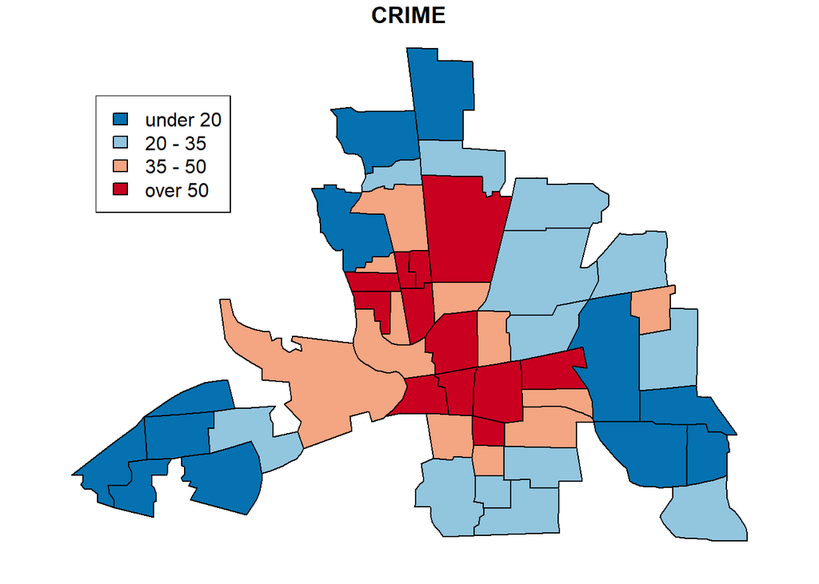

```r
color.code.fitted <- findColours(class.fitted, color.pallete)
brks <- c(-Inf,20,35,50,Inf)
plot(columbus[,9],col=color.code.fitted)
legend("topleft", fill=color.pallete, legend=leglabs(brks))
```

```r
#plot SAR predictions (regressing HOUSE_VAL+INCOME using distance-based nearest neighbors)
columbus$fitted.sar <- fitted(columbus.dnn.sar.out)
summary(columbus$fitted.sar)
```

```
##    Min. 1st Qu.  Median    Mean 3rd Qu.    Max.
##  -2.292  28.064  37.841  34.905  43.766  54.273
```

```r
brks <- c(0,20,35,50,70)
color.pallete <- rev(brewer.pal(4,"RdBu"))
class.fitted <- classIntervals(var=columbus$fitted.sar,n=4,style="fixed",
fixedBreaks=brks,dataPrecision=4)
class.fitted
```

```
## style: fixed
##   one of 17,296 possible partitions of this variable into 4 classes
##  [0,20) [20,35) [35,50) [50,70]
##       6      16      23       4
```

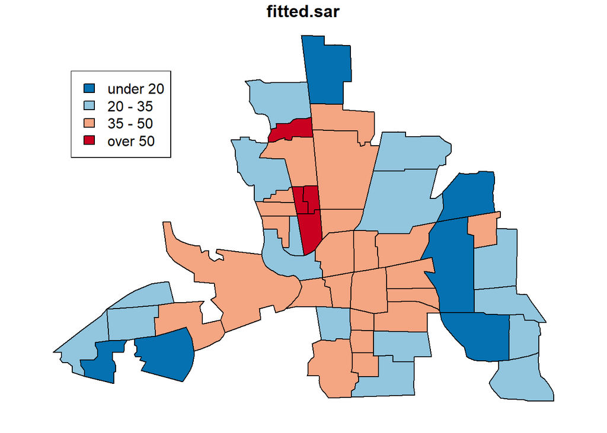

```r
color.code.fitted <- findColours(class.fitted, color.pallete)
brks <- c(-Inf,20,35,50,Inf)
plot(columbus[,22],col=color.code.fitted)
legend("topleft", fill=color.pallete, legend=leglabs(brks))
```

```r
#plot CAR predictions (regressing HOUSE_VAL+INCOME using distance-based nearest neighbors)
columbus$fitted.car <- fitted(columbus.dnn.car.out)
summary(columbus$fitted.sar)
```

```
##    Min. 1st Qu.  Median    Mean 3rd Qu.    Max.
##  -2.292  28.064  37.841  34.905  43.766  54.273
```

```r
brks <- c(0,20,35,50,70)
color.pallete <- rev(brewer.pal(4,"RdBu"))
class.fitted <- classIntervals(var=columbus$fitted.car,n=4,style="fixed",
fixedBreaks=brks,dataPrecision=4)
class.fitted
```

```
## style: fixed
##   one of 17,296 possible partitions of this variable into 4 classes
##  [0,20) [20,35) [35,50) [50,70]
##       6      16      22       5
```

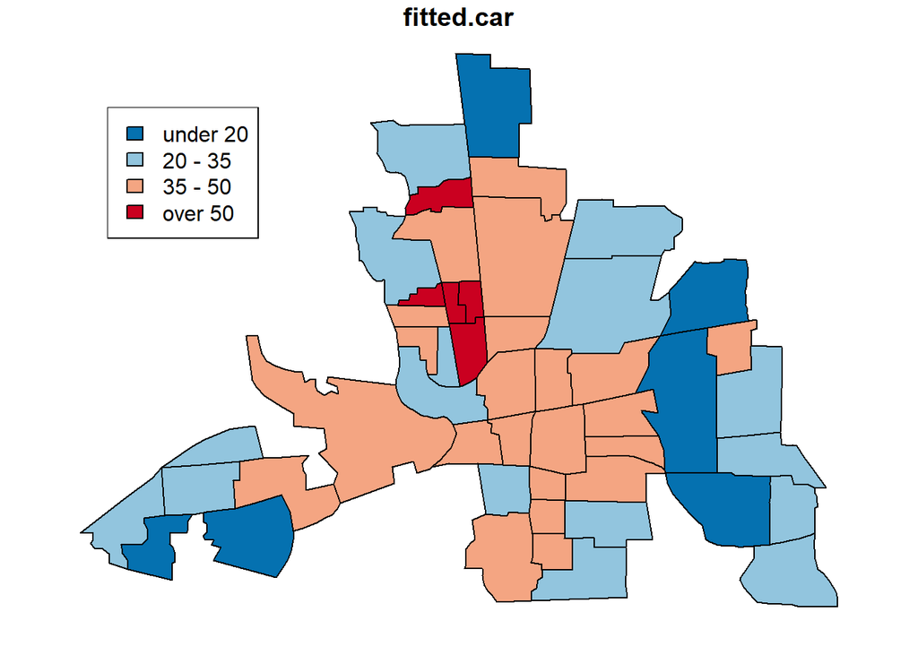

```r
color.code.fitted <- findColours(class.fitted, color.pallete)
brks <- c(-Inf,20,35,50,Inf)
plot(columbus[,23],col=color.code.fitted)
legend("topleft", fill=color.pallete, legend=leglabs(brks))
```

```r
##Draw the maps using the spplot (trellis) graphics function
#postscript(file="nc_sids_sar_actual.eps")
#print(spplot(nc.sids, "rates.FT", at = brks, col.regions = rev(brewer.pal(4,"RdBu")), main="a) Actual SIDS rates"))
#dev.off()
#postscript(file="nc_sids_sar_fitted.eps")
#print(spplot(nc.sids, "fitted.sar", at = brks, col.regions = rev(brewer.pal(4,"RdBu")), main="b) Fitted SIDS rates from SAR model"))
#dev.off()

##detach(package:spdep)
##detach(package:maptools)
##detach(package:RColorBrewer)
```